# Module 7 - Plan d’apprentissage

STT-1100 Introduction à la science des données

# 🎯 Objectifs du module

# 📚 Lectures

Pour vous préparer, consultez les ressources suivantes :

- 📘 [R for Data Science — Communication](https://r4ds.hadley.nz/communication.html)
- 📘 [Guide de bonnes pratiques à l’usage des data scientists (gouvernement du Luxembourg)](https://mindigital.gouvernement.lu/dam-assets/publications/guide-manuel/guide-data-scientists/fr-guide-de-bonnes-pratiques.pdf)

# 🧭 Aventure

Vous incarnerez un·e **expert·e en éthique des données** et serez chargé·e d’évaluer un rapport problématique.  
Lien vers l’aventure :  
👉 Aventure 7 — Visualisation, éthique et sécurisation des données

# 💡 Défi — Analyse éthique et visualisation responsable

Vous recevrez un jeu de données COVID simulé. Votre tâche sera de produire une analyse responsable :

- Évaluer les aspects éthiques liés à la visualisation fournie.
- Anonymiser correctement les données.
- Créer une nouvelle visualisation fidèle et informative.
- Rédiger une réflexion critique sur les enjeux rencontrés.

# 🏋️ Exercices de consolidation

Voici quelques exemples réels de visualisations problématiques ou controversées à analyser :

[figure not shown]

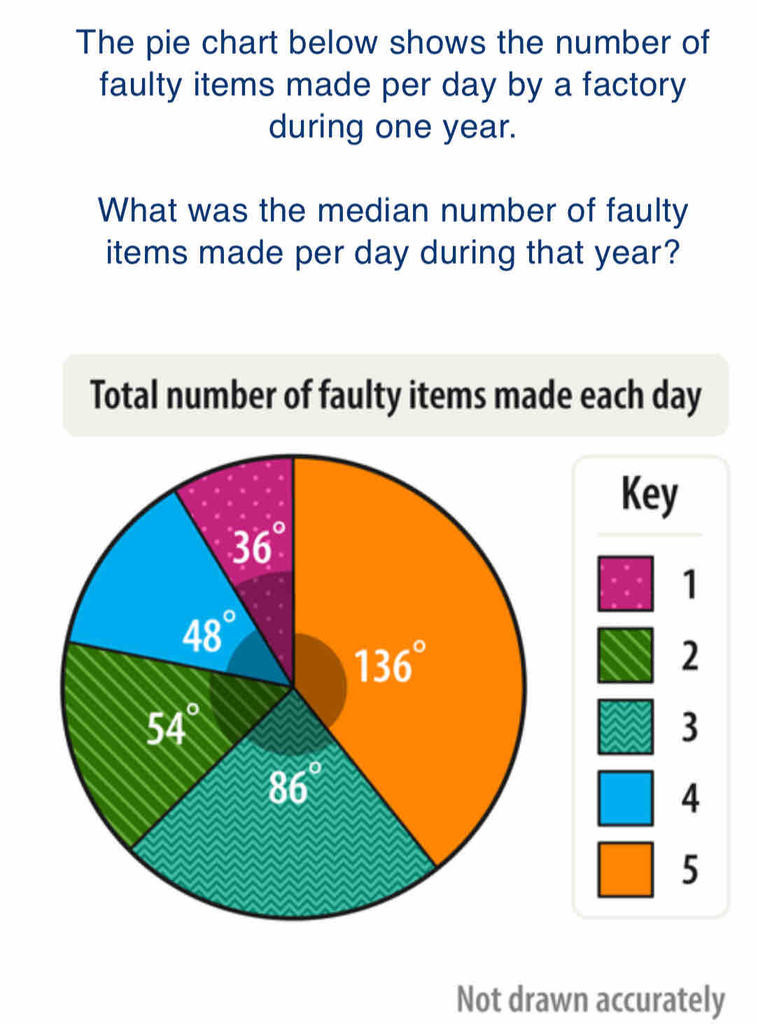

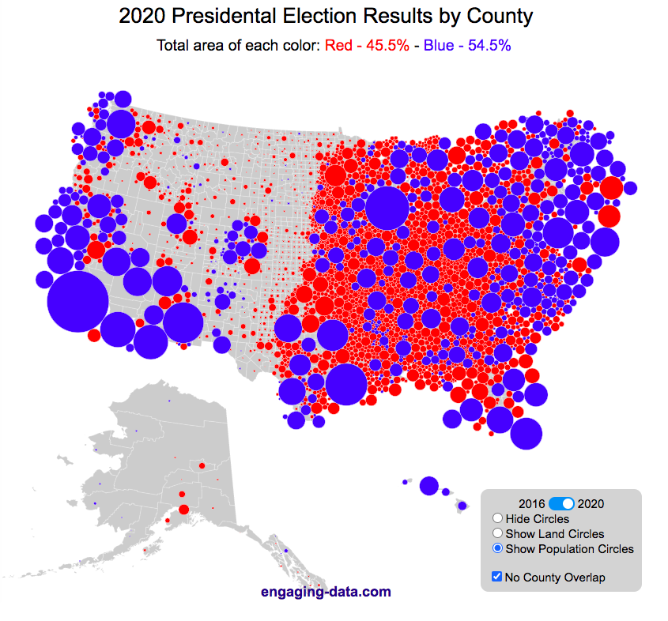

   **➤ Question** : Pourquoi la taille géographique peut-elle fausser la perception des résultats ? Comment faire mieux ?
4. **Ticked Axis – Exemple pédagogique de manipulation**  
   Deux versions d’un même graphique, l’une honnête et l’autre manipulée par troncature d’axe, révèlent l’impact des choix visuels.

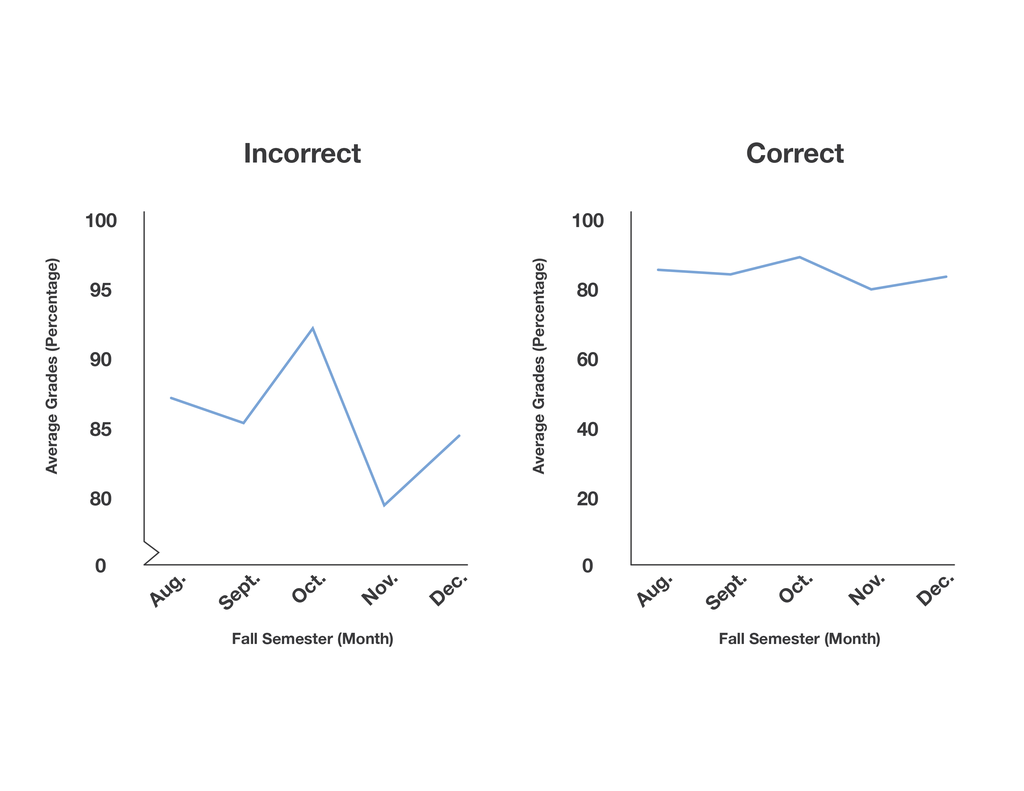

   **➤ Question** : Que remarquez-vous en comparant les deux versions ? Quels messages différents sont véhiculés ?
5. **Cambridge Analytica – Profilage psychologique sans consentement**  
   Données Facebook utilisées à l’insu des utilisateur·rices à des fins de manipulation électorale.  
   https://fr.wikipedia.org/wiki/Cambridge_Analytica  
   **➤ Question** : Quels principes éthiques sont ici violés (transparence, consentement, anonymisation) ? Comment prévenir ce type de dérive ?